# HW 5

2024-04-09

Импорт датасета

## Задание 1

Создайте регрессионную модель, которая бы описывала связь среднего радиуса опухоли и средней площади (а), среднего периметра (б), средней симметричности (в).

Постройте графики, на которых отразите регрессионную прямую, и прокомментируйте свои находки.

```r
# Строим модель линейной регрессии
# Допущения и условия:
#   Линейность связи между предиктором (x) и исходом (y)
#   Нормальность распределения остатков.
#   Гомоскедастичность
#   Отсутствие выбросов
#   Отутствие мультиколлинеарности
#   Отутствие корреляции предикторов с факторами, не включенными в модель
fit1 <- lm(radius_mean ~ area_mean + perimeter_mean + symmetry_mean, data = data)
summary(fit1)
```

```
##
## Call:
## lm(formula = radius_mean ~ area_mean + perimeter_mean + symmetry_mean,
##     data = data)
##
## Residuals:
##      Min       1Q   Median       3Q      Max
## -0.89375 -0.08980  0.01347  0.12073  0.71670
##
## Coefficients:
##                  Estimate Std. Error t value Pr(>|t|)
## (Intercept)     2.0101598  0.1014135   19.82  < 2e-16 ***
## area_mean       0.0007378  0.0001405    5.25 2.16e-07 ***
## perimeter_mean  0.1350754  0.0020466   66.00  < 2e-16 ***
## symmetry_mean  -4.3541675  0.3004459  -14.49  < 2e-16 ***
## ---
## Signif. codes:  0 '***' 0.001 '**' 0.01 '*' 0.05 '.' 0.1 ' ' 1
##
## Residual standard error: 0.1898 on 565 degrees of freedom
## Multiple R-squared:  0.9971, Adjusted R-squared:  0.9971
## F-statistic: 6.511e+04 on 3 and 565 DF,  p-value: < 2.2e-16
```

Анализ результатов:

P value для всех факторов меньше уровня значимости, а значит связь во всех случаях стат. значима.

Adjusted R-squared = 0.997 - данный показатель отражает точность нашей модели, но мне кажется в нашем случае пока стоит относится к нему скептично (слишком хорошо чтобы быть правдой :) )

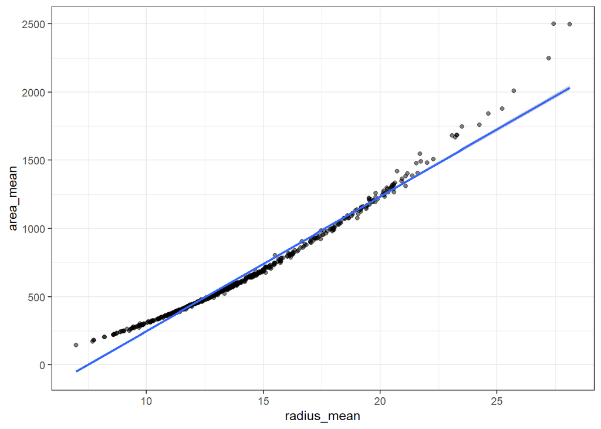

```r
# Проверим допущения для модели
# Визуальный анализ линейной зависимости между:
# радиусом и площадью
data %>%
  ggplot(aes(radius_mean, area_mean)) +
  geom_point(alpha = 0.5) +
  geom_smooth(method = 'lm') +
  theme_bw()
```

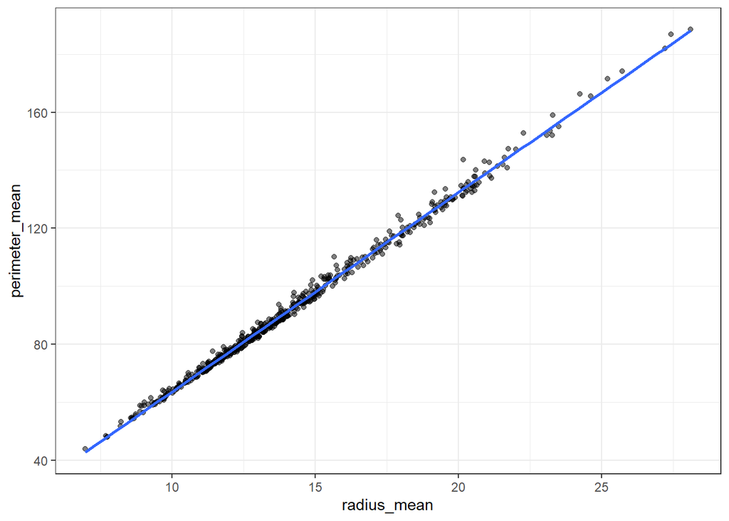

```r
# радиусом и периметром
data %>%
  ggplot(aes(radius_mean, perimeter_mean)) +
  geom_point(alpha = 0.5) +
  geom_smooth(method = 'lm') +
  theme_bw()
```

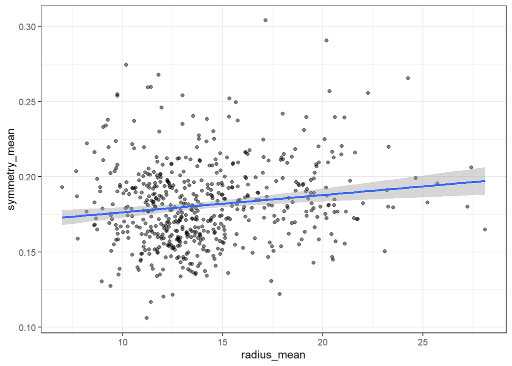

```r
# радиусом и симметрией
data %>%
  ggplot(aes(radius_mean, symmetry_mean)) +
  geom_point(alpha = 0.5) +
  geom_smooth(method = 'lm') +
  theme_bw()
```

В случаях с площадью и периметром можно уверенно сказать, что линейная зависимость есть. А в случае с симметрией можно сказать, что связь есть, но она менее явная, чем в первых двух случаях. (или ее нет ? - оставьте небольшой комментарий по этому поводу)

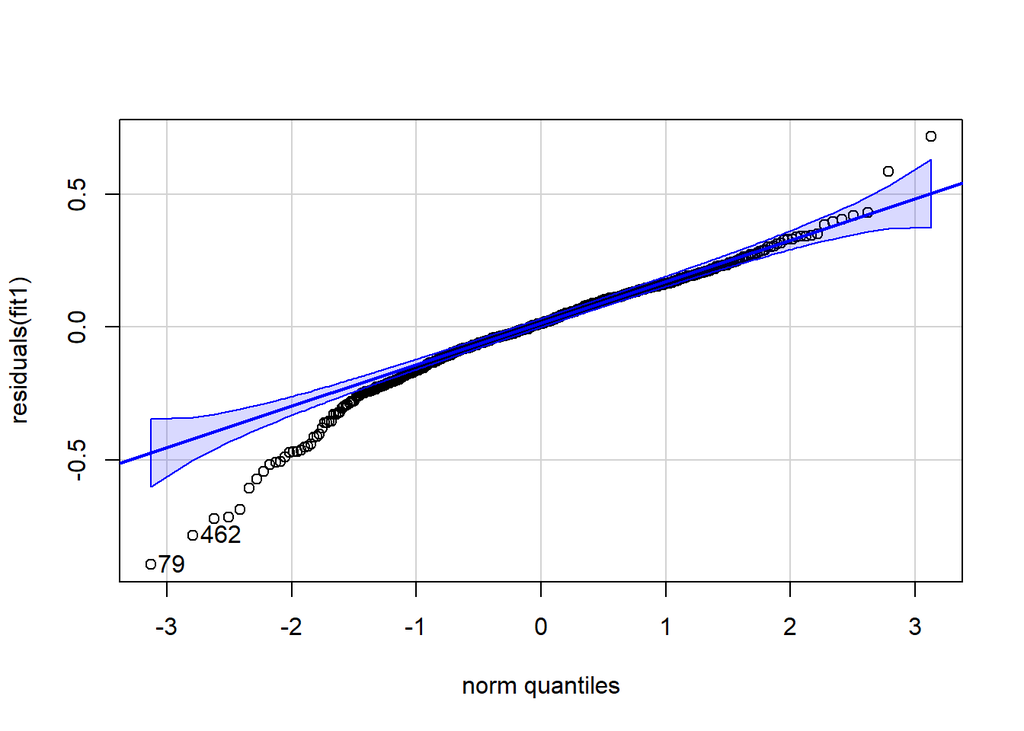

```
## [1]  79 462
```

```r
# Нормальное распределение остатков
qqPlot(residuals(fit1))
```

```r
shapiro.test(residuals(fit1))
```

```
##
##  Shapiro-Wilk normality test
##
## data:  residuals(fit1)
## W = 0.95781, p-value = 1.072e-11
```

Оценивая визуально распределение остатков, можно сказать, что ощутимая доля лежит вне доверительных интервалов и вероятнее всего остатки распределены ненормально.

Результат теста Шапиро Уилка на нормальность подтверждает наше утверждение.

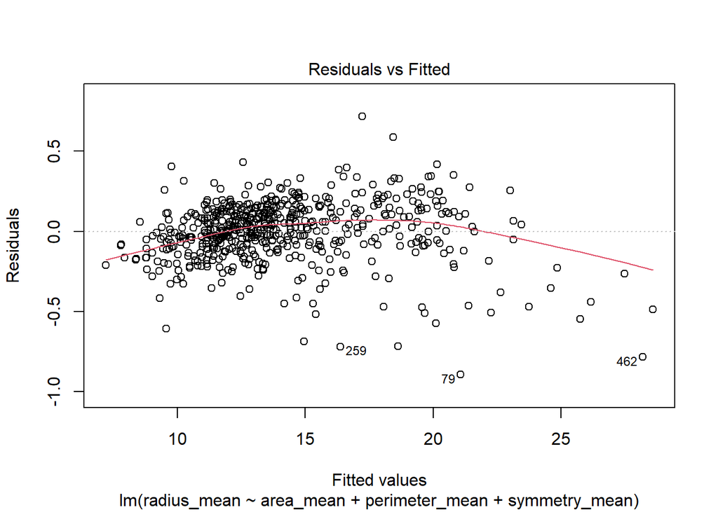

```r
# гомоскедастичность остатков
plot(fit1, which = 1)
```

Наблюдается неравномерность распределения - в левой половине графика точек значительно больше, чем в правой.

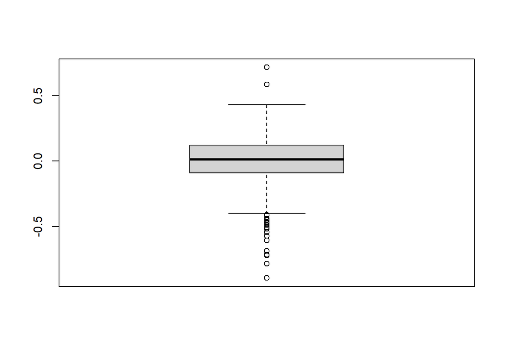

```r
# выбросы
boxplot(fit1$residuals)
```

```r
# есть существенное кол-во выбросов
```

```r
# мультиколлинеарность признаков
seleceted_data <- data[c('area_mean', 'perimeter_mean', 'symmetry_mean')]
cor(seleceted_data)
```

```
##                area_mean perimeter_mean symmetry_mean
## area_mean      1.0000000      0.9865068     0.1512931
## perimeter_mean 0.9865068      1.0000000     0.1830272
## symmetry_mean  0.1512931      0.1830272     1.0000000
```

Признаки средней площади и периметра сильно кореллируют между собой, один из них следовало бы удалить, не берусь предполагать какой именно, тк это совершенно комплексная задача.

**Итого**: наша модель соответствует не всем дорпущениям, следовательно ее результаты могут обладать меньшей точностью, чем кажется на первый взгляд (adjusted R squared вспоминаем).

## Задание 2

Пусть колонка с диагнозом принимает следующие значения: злокачественная опухоль — 1, а доброкачественная — 0. Постройте модель, которая бы прогнозировала вероятность возникновения злокачественной опухоли от среднего радиуса (а), средней площади (б), средней текстуры (в).

Постройте графики. Создайте модель, которая бы прогнозировала вероятность возникновения злокачественной опухоли от всех трех перечисленных факторов.

На этапе этого задания у меня закралось сомнение - а нужно построить 3 модели по каждому из факторов и потом общую, либо просто общую модель. Остановился на предположениии об общей модели - вы говорили, что не критично важно как интерпретировать задание :))

```r
# преобразование значений в diagnosis
data$diagnosis <- ifelse(data$diagnosis == 'M', 1, 0)
head(data)
```

```
##         id diagnosis radius_mean texture_mean perimeter_mean area_mean
## 1   842302         1       17.99        10.38         122.80    1001.0
## 2   842517         1       20.57        17.77         132.90    1326.0
## 3 84300903         1       19.69        21.25         130.00    1203.0
## 4 84348301         1       11.42        20.38          77.58     386.1
## 5 84358402         1       20.29        14.34         135.10    1297.0
## 6   843786         1       12.45        15.70          82.57     477.1
##   smoothness_mean compactness_mean concavity_mean concave.points_mean
## 1         0.11840          0.27760         0.3001             0.14710
## 2         0.08474          0.07864         0.0869             0.07017
## 3         0.10960          0.15990         0.1974             0.12790
## 4         0.14250          0.28390         0.2414             0.10520
## 5         0.10030          0.13280         0.1980             0.10430
## 6         0.12780          0.17000         0.1578             0.08089
##   symmetry_mean fractal_dimension_mean radius_se texture_se perimeter_se
```

[output cut: 34 more lines]

```r
fit2 <- glm(diagnosis ~ radius_mean + area_mean + texture_mean, data, family = 'binomial')
summary(fit2)
```

```
##
## Call:
## glm(formula = diagnosis ~ radius_mean + area_mean + texture_mean,
##     family = "binomial", data = data)
##
## Coefficients:
##              Estimate Std. Error z value Pr(>|z|)
## (Intercept)  -9.48796    6.88503  -1.378    0.168
## radius_mean  -0.38523    0.95524  -0.403    0.687
## area_mean     0.01636    0.01100   1.487    0.137
## texture_mean  0.20917    0.03714   5.632 1.78e-08 ***
## ---
## Signif. codes:  0 '***' 0.001 '**' 0.01 '*' 0.05 '.' 0.1 ' ' 1
##
## (Dispersion parameter for binomial family taken to be 1)
##
##     Null deviance: 751.44  on 568  degrees of freedom
## Residual deviance: 288.81  on 565  degrees of freedom
## AIC: 296.81
##
## Number of Fisher Scoring iterations: 7
```

```r
exp(fit2$coefficients)
```

```
##  (Intercept)  radius_mean    area_mean texture_mean
## 7.575823e-05 6.802975e-01 1.016495e+00 1.232654e+00
```

Интерпретация результатов:

- radius_mean и area_mean имеют p value > 0.05 -> стат. незначимы для зависимого признака
- texture_mean имеет p value < 0.05 -> данный признак статистически значим для целевой переменной
- После взятия экспоненты коэффициентов можем сделать вывод о том, что при увеличении признака texture_mean ( на 1 ??? ) шанс наличия события переменной diagnosis увеличится в 1.23 раза. Другими словами при росте параметра “средней текстуры” увеличивается риск того, что опухоль злокачественная (на основе наших данных). Если правильно понимаю, то здесь именно risk а не odds имеется ввиду ( тоже хотел бы микро-коммент - прав я или нет)

В данном случае имеет место визуализация только параметра текстуры, тк другие оказались незначимы.

[figure not shown]

```r
data %>%
    ggplot(aes(x = texture_mean, y = diagnosis)) +
    geom_point() +
    labs(
      x = "Средняя площадь опухоли",
      y = "Тип опухоли") +
    geom_smooth(method = "glm",
                method.args = list(family = "binomial")) +
  theme_bw()
```

Не могу понять как интерпретировать график…

**“Создайте модель, которая бы прогнозировала вероятность возникновения злокачественной опухоли от всех трех перечисленных факторов.”:**

```r
fit3 <- glm(diagnosis ~ radius_mean * area_mean * texture_mean, data, family = 'binomial')
summary(fit3)
```

```
##
## Call:
## glm(formula = diagnosis ~ radius_mean * area_mean * texture_mean,
##     family = "binomial", data = data)
##
## Coefficients:
##                                      Estimate Std. Error z value Pr(>|z|)
## (Intercept)                         1.644e+00  4.075e+01   0.040    0.968
## radius_mean                        -1.532e+00  8.238e+00  -0.186    0.852
## area_mean                           3.909e-02  1.936e-01   0.202    0.840
## texture_mean                       -2.041e-01  2.104e+00  -0.097    0.923
## radius_mean:area_mean              -1.071e-03  4.984e-03  -0.215    0.830
## radius_mean:texture_mean            3.641e-02  4.191e-01   0.087    0.931
## area_mean:texture_mean             -9.528e-04  9.810e-03  -0.097    0.923
## radius_mean:area_mean:texture_mean  5.835e-05  2.563e-04   0.228    0.820
##
## (Dispersion parameter for binomial family taken to be 1)
##
##     Null deviance: 751.44  on 568  degrees of freedom
## Residual deviance: 282.35  on 561  degrees of freedom
## AIC: 298.35
##
## Number of Fisher Scoring iterations: 10
```

```r
exp(fit3$coefficients)
```

```
##                        (Intercept)                        radius_mean
##                          5.1764381                          0.2161074
##                          area_mean                       texture_mean
##                          1.0398643                          0.8153730
##              radius_mean:area_mean           radius_mean:texture_mean
##                          0.9989297                          1.0370826
##             area_mean:texture_mean radius_mean:area_mean:texture_mean
##                          0.9990477                          1.0000584
```

Ни один из факторов или их взаимодействия не имеют статичстической значимости в изменении нашей переменной. Выходит данная модель хуже, чем модель с отдельным влиянием факторов.

## Задание 3

Для выполнения этого задания вам понадобится датасет `lung`, который встроен в пакет `survival`. Установите этот пакет и загрузите датасет.

Датасет содержит следующий набор переменных:

- `inst`: код учреждения;
- `time`: время выживаемости в днях;
- `status`: 1 = цензурирование, 2 = смерть;
- `age`: возраст в годах;
- `sex`: мужской = 1, женский = 2;
- `ph.ecog`: шкала опросника ECOG (оценку проводит врач). 0 = отсутствие симптомов, 1= симптомы есть, но пациент наблюдается амбулаторно, 2 = меньше половины дня пациент вынужден проводить в постели, 3 = больше половины дня нуждается в отдыхе лежа, но не прикован к постели, 4 = прикован к постели;
- `ph.karno`: шкала Карновского (от 0 до 100, от худшего к лучшему) по оценке врача;
- `pat.karno`: шкала Карновского (от 0 до 100, от худшего к лучшему) по оценке пациента;
- `meal.cal`: калории потребляемой пищи;
- `wt.loss`: потеря веса за последние полгода.

Создайте переменную `event`, в которой отразите наличие или отсутствие (1 или 0) интересующего события — смерти пациента.

Изучите работу функций `Surv()`, `survfit()` и `ggsurvplot()`:

- Постройте кривые выживаемости в зависимости от пола (на одном графике должны получиться две кривые для каждого пола и таблица числа пациентов, подверженных риску (at risk) под ним). Поясните получившееся значение p-value для лог-рангового теста и опишите наблюдаемые результаты.
- Постройте график кумулятивной функции рисков (cumulative hazard function) для пола. Проинтерпретируйте график.
- С помощью функции `coxph()` постройте регрессию Кокса и оцените влияние пола на выживаемость. Что вы можете сказать о полученных результатах?

```r
library(survival)
library(ggsurvfit)
library(survminer)
lung_data <- survival::lung
head(lung_data)
```

```
##   inst time status age sex ph.ecog ph.karno pat.karno meal.cal wt.loss
## 1    3  306      2  74   1       1       90       100     1175      NA
## 2    3  455      2  68   1       0       90        90     1225      15
## 3    3 1010      1  56   1       0       90        90       NA      15
## 4    5  210      2  57   1       1       90        60     1150      11
## 5    1  883      2  60   1       0      100        90       NA       0
## 6   12 1022      1  74   1       1       50        80      513       0
```

```r
# создание перменной event (наличие факта смерти)
lung_data$event <- ifelse(lung_data$status == 2, 1, 0)
```

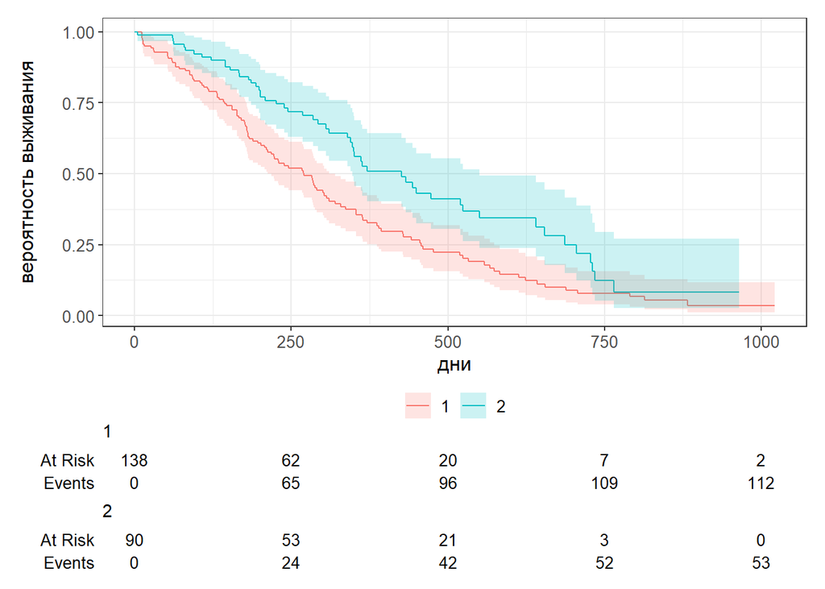

```r
# график выживаемости с разделением по полу
surv_fit <- survfit2(Surv(time, event) ~ sex, data = lung_data)
surv_fit %>%
  ggsurvfit(type = 'survival')+
  labs(
    x='дни',
    y='вероятность выживания'
  )+
  add_confidence_interval()+
  add_risktable()
```

```r
# лог-ранг тест
survdiff(Surv(time, event)~sex, lung_data)
```

```
## Call:
## survdiff(formula = Surv(time, event) ~ sex, data = lung_data)
##
##         N Observed Expected (O-E)^2/E (O-E)^2/V
## sex=1 138      112     91.6      4.55      10.3
## sex=2  90       53     73.4      5.68      10.3
##
##  Chisq= 10.3  on 1 degrees of freedom, p= 0.001
```

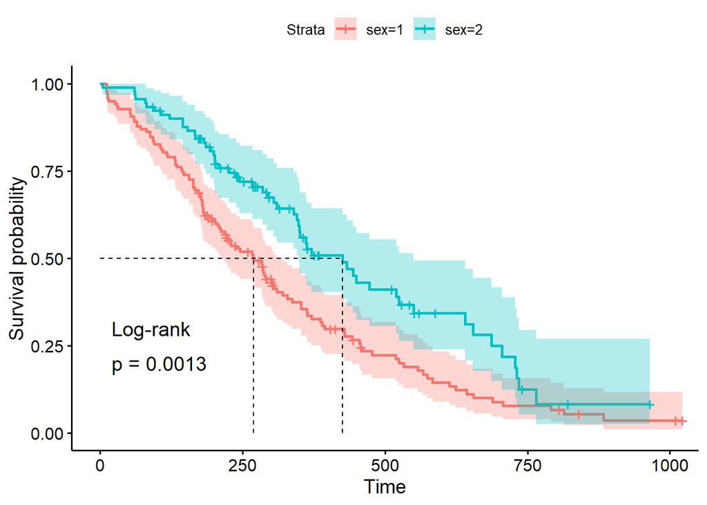

```r
ggsurvplot(surv_fit,
           conf.int = TRUE,
           surv.median.line = 'hv',
           pval = TRUE,
           pval.method = TRUE)
```

Значение p-value < 0.05 означает, что есть значимые статистические различия между группой женщин и мужчин.

“Ступени” на графиках означают наступление интересующего нас события, в данном сулчае смерть пациента. “Крестики” отображают событие цензурирования.

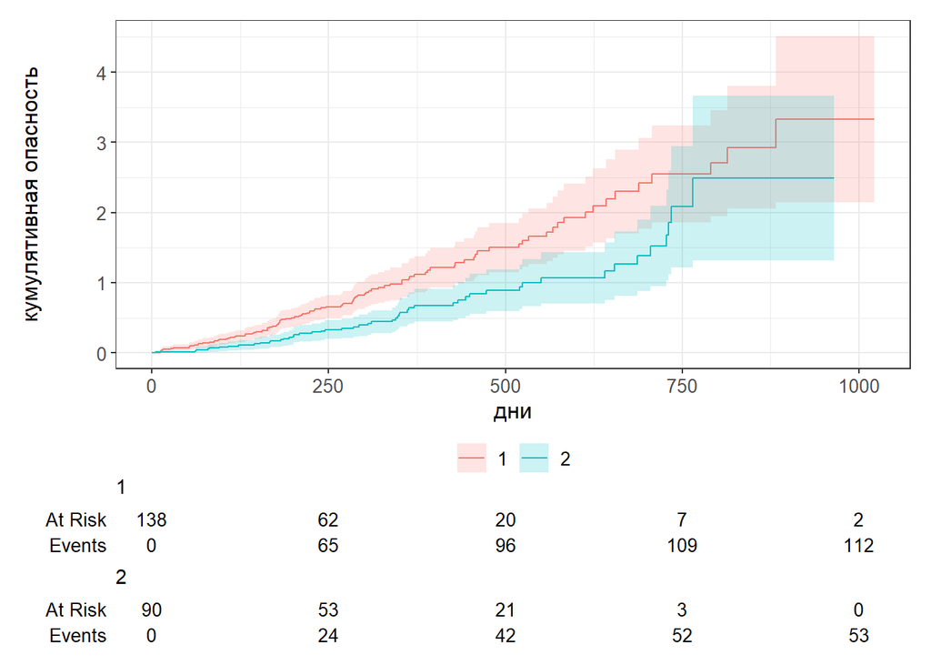

```r
# график кумулятивной функции рисков
surv_fit %>%
  ggsurvfit(type = 'cumhaz')+
  labs(
    x='дни',
    y='кумулятивная опасность')+
  add_confidence_interval()+
  add_risktable()
```

На графике мы наблюдаем зависимость риска смерти от времени (чем более продолжительное время человек болен, тем выше шанс смертельного исхода). Доверительные интервалы двух групп множественно пересекаются, сами линии графиков нет. Для вывода о статистической значимости различий необходимо построить модель пропорциональных опасностей Кокса.

```r
# модель регрессии Кокса
cox <- coxph(Surv(time, event)~sex, lung_data)
cox
```

```
## Call:
## coxph(formula = Surv(time, event) ~ sex, data = lung_data)
##
##        coef exp(coef) se(coef)      z       p
## sex -0.5310    0.5880   0.1672 -3.176 0.00149
##
## Likelihood ratio test=10.63  on 1 df, p=0.001111
## n= 228, number of events= 165
```

```r
summary(cox)
```

```
## Call:
## coxph(formula = Surv(time, event) ~ sex, data = lung_data)
##
##   n= 228, number of events= 165
##
##        coef exp(coef) se(coef)      z Pr(>|z|)
## sex -0.5310    0.5880   0.1672 -3.176  0.00149 **
## ---
## Signif. codes:  0 '***' 0.001 '**' 0.01 '*' 0.05 '.' 0.1 ' ' 1
##
##     exp(coef) exp(-coef) lower .95 upper .95
## sex     0.588      1.701    0.4237     0.816
##
## Concordance= 0.579  (se = 0.021 )
## Likelihood ratio test= 10.63  on 1 df,   p=0.001
## Wald test            = 10.09  on 1 df,   p=0.001
## Score (logrank) test = 10.33  on 1 df,   p=0.001
```

Выводы:

- p-value меньше 0.05 следовательно результаты модели \ теста статистически значимы
- шанс умереть от рака легких среди женщин на 41.2% меньше, чем среди мужчин (1 - exp(coef) * 100
- шанс умереть от рака легких среди мужчин больше на 70.1%, чем среди женщин.

  Таким образом благодаря построению регрессионной модели Кокса мы получили количественные данные разницы выживаемости больных раком легких среди женщин и мужчин.